# Third Week: Exploratory Data Analysis

### پاسخ:

ابتدا بررسی می کنیم که کدام تیم ها در تمام فصول توانسته اند نتیج بازی های باخنه را به نفع خود برگردانند. به این منظور از دو معیار استفاده کرده و میانگین وزن دار آن ها را به عنوان معیار نهایی در نظر می گیریم. معیار اول: هر تیم، چند درصد از بازی هایی که در نیمه ی اول باخنه است را نهایتا برده است. معیار دوم: هر تیم چند درصد از بازی هایی که در نیمه ی اول باخته است را نهایتا برده است و اختلاف گل در نیمه ی اول آن بازی ها بیشتر مساوی 2 بوده است. معیار اول را با وزن 0.7 و معیار دوم را با وزن 0.3 در نظر می گیریم و نمودار ده تیم با بیشترین معیار را رسم می کنیم.

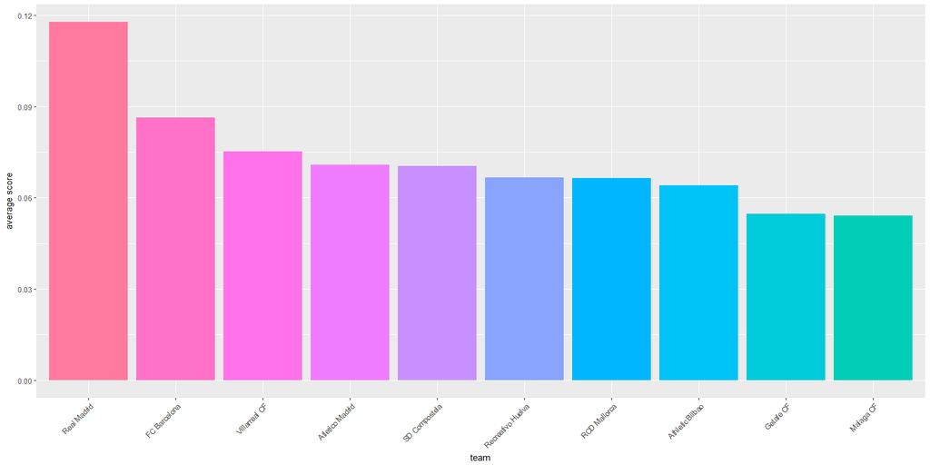

```r
spain$hgoal_half = as.numeric(substr(spain$HT, 1, 1))
spain$vgoal_half = as.numeric(substr(spain$HT, 3, 3))


rbind(
  spain %>% filter(!is.na(HT)) %>%
    select(Season, Date, team = home, opp = visitor, GF = hgoal, GA = vgoal,
           GFH = hgoal_half, GAH = vgoal_half),
  spain %>% filter(!is.na(HT)) %>%
    select(Season, Date, team = visitor, opp = home, GF = vgoal, GA = hgoal,
           GFH = vgoal_half, GAH = hgoal_half)
) %>% mutate(GD = GF-GA , GDH = GFH-GAH) %>%
  mutate(W = ifelse(GD > 0,1,0),
         D = ifelse(GD == 0,1,0),
         L = ifelse(GD < 0,1,0),
         WH = ifelse(GDH > 0,1,0),
         DH = ifelse(GDH == 0,1,0),
         LH = ifelse(GDH < 0,1,0)
  ) %>% group_by(team) %>%
  summarise(L = sum(LH==1),score = (0.7*sum(LH==1&W==1)+0.3*sum(GDH<=-2 & W==1))/sum(LH==1)) %>%
  arrange(score) %>% arrange(-score) %>% slice(1:10) -> stat

ggplot(data = stat) + geom_bar(aes(x = reorder(team,-score),y =score ,fill = reorder(team,-score)),stat = "identity") +
  theme(axis.text.x = element_text(angle = 45, hjust = 1, vjust = 1),legend.position = "none") +
  scale_fill_hue(h=c(360,180),l=70) + xlab("team") + ylab("average score")
```

```r
hchart(stat,type = "column", hcaes(x = team, y = score,color = score),name = "average score") %>%
  hc_xAxis(title = list(text = "team")) %>%
  hc_yAxis(title = list(text = "average score")) %>% hc_add_theme(hc_theme_economist())
```

[interactive chart not shown]

حال بررسی می کنیم که در 20 سال اخیر یعنی 1997 تا 2016، به طور میانگین، تعداد بازی های پرگل در هفته های مختلف لیگ چگونه تغییر می کند. به این منظور در هرهفته بررسی می کنیم که چند درصد بازی ها بیش از 3 گل داشته اند و بین این 20 سال میانگین می گیریم.

```r
laliga2 %>% filter(Season<=2016 & Season>=1997) %>% group_by(play) %>%
  summarise(percent = sum((GF+GA)>=4)/n()) %>%
  hchart(type = "line", hcaes(x = play, y = percent), name = "Percent") %>%
  hc_yAxis(title = list(text = "Percent of Plays with high number of goals")) %>%
  hc_xAxis(title = list(text = "Week")) %>% hc_add_theme(hc_theme_db())
```

[interactive chart not shown]

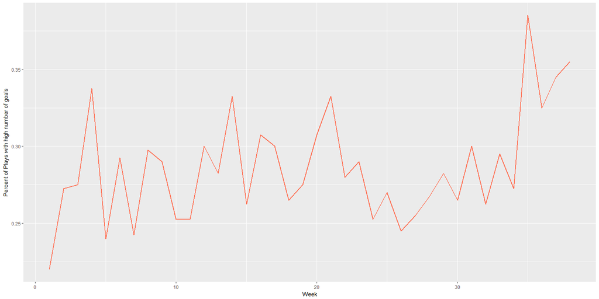

```r
laliga2 %>% filter(Season<=2016 & Season>=1997) %>% group_by(play) %>%
  summarise(percent = sum((GF+GA)>=4)/n()) %>%
  ggplot() + geom_line(aes(x = play, y = percent),size=1,color = "coral1") +
  xlab("Week") + ylab("Percent of Plays with high number of goals")
```

به نظر می رسدکه در هفته های اول تیم که تیم ها پرانرژی اند تعداد خوبی از بازی ها پرگل هستند .از هفته ی 24م تا 34م تعداد بازی های پرگل کاهش می یابد که نشان دهنده ی کم شدن توان فیزیکی بازیکنان در اواسط لیگ است. اما در هفته های آخر که هفته های تعیین کننده ای برای قهرمانی و نیز سقوط می باشد، تعداد بازی های پرگل افزایش می یابد.

در انتها می خواهیم بررسی کنیم که دفاع خوب داشتن در به دست آوردن رتبه ی خوب در لیگ موثرتر است یا حمله ی خوب داشتن. به این منظور معیار دفاع خوب را کم گل خوردن در لیگ و معیار حمله ی خوب را زیاد گل زدن در نظر می گیریم.حال برای هر یک از لیگ های 2997 تا 2016، پنج تیم با بهترین دفاع، پنج تیم با بهترین حمله و پنج تیم اول لیگ را می یابیم و بررسی می کنیم چند درصد از 5تیم با بهترین دفاع در بین 5تیم اول لیگ بوده اند. همین معیار را برای تیم ها با بهترین دفاع به دست می آوریم و نمودار آن ها را رسم می کنیم.

```r
years = c(1997:2016)
attack = c()
defense = c()
for (year in years){
  laliga2 %>% filter(Season == year) %>% filter(play==max(play) & rank<=5) %>% .$team -> first_teams
  laliga2 %>% filter(Season == year) %>% filter(play==max(play)) %>% group_by(team) %>%
    summarise(def = sum(GA), att = sum(GF))->stat
  stat %>% arrange(def) %>% slice(1:5) %>%  .$team -> teams_def
  stat %>% arrange(-att) %>% slice(1:5) %>%  .$team -> teams_att
  attack = c(attack, sum(teams_att %in% first_teams)/5*100)
  defense = c(defense, sum(teams_def %in% first_teams)/5*100)
}
stat = rbind(data.frame(years,percent = attack, strategy = "attack"),
             data.frame(years,percent = defense, strategy = "defense"))


stat %>%
  hchart(type = "line", hcaes(x = years, y = percent, group = strategy)) %>%
  hc_legend(align = "right", verticalAlign = "top",
            layout = "vertical", x = 0, y = 100)
```

[interactive chart not shown]

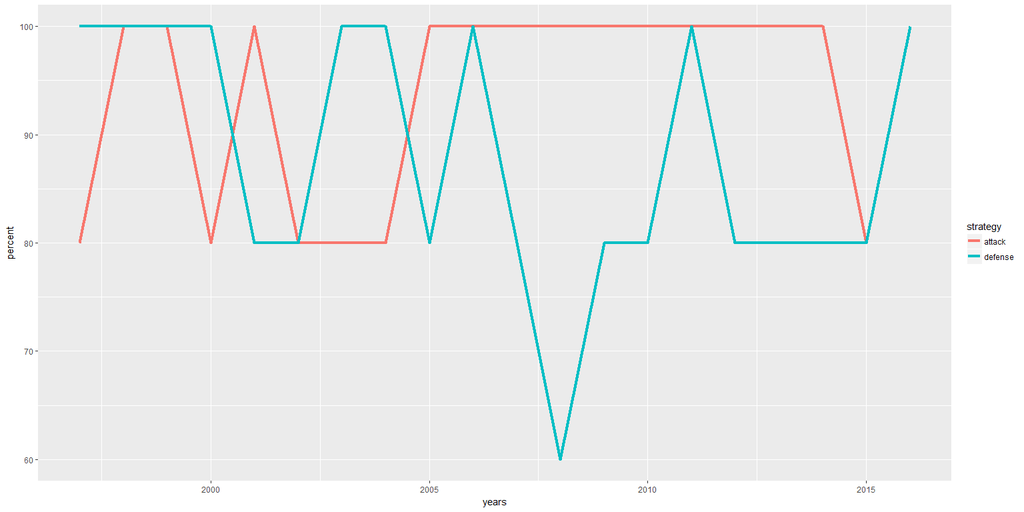

```r
stat %>%
  ggplot()+geom_line(aes(x= years, y=percent, group= strategy,colour = strategy),size=1.5)
```

همان طور که نمودارها نشان می دهند به نظر می رسد که حمله ی خوب داشتن در به دست آوردن رتبه ی خوب در جدول موثرتر است و تعداد زیادی از لیگ ها 5تیم اول از لحاظ حمله 5تیم اول لیگ بوده اند. (گرچهنباید از این غافل شده این دو از هم مستقل نیستند و خیلی اوقات تیم های با بهترین حمله، تیم های با بهترین دفاع نیز هستند و این امر می تواند بر رتبه ی خوب آن ها موثر باشد)